# Dates

Richard Ressler

2020-01-26

# 1 Learning Outcomes

- Manipulate dates and times using `lubridate`.

## 1.1 References

- Chapter 16 of [RDS](https://r4ds.had.co.nz/).
- [Dates and Times Cheat Sheet](https://github.com/rstudio/cheatsheets/blob/master/lubridate.pdf).
- [Lubridate Overview](https://lubridate.tidyverse.org/).

# 2 The `lubridate` Package

- The lubridate package has a bunch of convenience functions for working with dates.
  - It is *not* a part of the tidyverse, so you need to install the package (using the console) and then load it separately.

    ```r
    library(tidyverse)
    library(lubridate)
    ```

## 2.1 Three main classes for date/time data

```
1. `Date` for just the date.
2. `POSIXct` for both the date and the time (with Time Zone).
    + "POSIXct" stands for "Portable Operating System Interface - Calendar Time". It is a part of a [standardized system](https://en.wikipedia.org/wiki/Unix_time) (based on UNIX) of representing time across many computing computing platforms.
3. `hms` from the `hms` R package for just the time. "hms" stands for "hours, minutes, and seconds."
```

- `today()` will give you the current date in the `Date` class.

  ```r
  today()
  ```

  ```
  ## [1] "2020-01-26"
  ```

  ```r
  class(today())
  ```

  ```
  ## [1] "Date"
  ```

- `now()` will give you the current date-time in the `POSIXct` class.

  ```r
  now()
  ```

  ```
  ## [1] "2020-01-26 15:52:46 EST"
  ```

  ```r
  class(now())
  ```

  ```
  ## [1] "POSIXct" "POSIXt"
  ```

- There is no built-in R function to find the current time without the date. But you can use `hms::as_hms(now())` to get the current time.

  ```r
  hms::as_hms(now())
  ```

  ```
  ## 15:52:46.828176
  ```

  ```r
  class(hms::as_hms(now()))
  ```

  ```
  ## [1] "hms"      "difftime"
  ```

# 3 Parsing Dates and Times

## 3.1 Parsing Dates and times Using `readr`

- `readr` functions `parse_date()`, `parse_datetime()`, and `parse_time()` parse a date/date-time/time from a string.

  ```r
  x <- parse_date("10/11/2020", format = "%m/%d/%Y")
  x
  ```

  ```
  ## [1] "2020-10-11"
  ```

  ```r
  class(x)
  ```

  ```
  ## [1] "Date"
  ```

  ```r
  y <- parse_datetime("10/11/2020 11:59:20", format = "%m/%d/%Y %H:%M:%S")
  y
  ```

  ```
  ## [1] "2020-10-11 11:59:20 UTC"
  ```

  ```r
  class(y)
  ```

  ```
  ## [1] "POSIXct" "POSIXt"
  ```

  ```r
  z <- parse_time("11:59:20", "%H:%M:%S")
  z
  ```

  ```
  ## 11:59:20
  ```

  ```r
  class(z)
  ```

  ```
  ## [1] "hms"      "difftime"
  ```

## 3.2 Parsing Dates and Times Using `lubridate`

- `lubridate` comes with a bunch of helper functions to parse dates more automatically.
  - The helper function name itself specifies the order of the year, month, day, hours, minutes, and seconds.
- To parse **dates**, look at the help page of `ymd`

  ```r
  help(ymd)
  ```

- Only the order of year, month, and day matters

  ```r
  ymd(c("2011/01-10", "2011-01/10", "20110110"))
  ```

  ```
  ## [1] "2011-01-10" "2011-01-10" "2011-01-10"
  ```

  ```r
  mdy(c("01/10/2011", "01 adsl; 10 df 2011", "January 10, 2011"))
  ```

  ```
  ## [1] "2011-01-10" "2011-01-10" "2011-01-10"
  ```

- To parse **times**, look at the help page of `mds`

  ```r
  help(ms)
  ```

- Only the order of the hours, minutes, and seconds matter

  ```r
  hms(c("10:40:10", "10 40 10"))
  ```

  ```
  ## [1] "10H 40M 10S" "10H 40M 10S"
  ```

- Note: `ms()`, `hm()`, and `hms()` don’t recognize “`-`” as a separator because they treat it as negative time. So use `parse_time()` here.

  ```r
  ms("10-10")
  ```

  ```
  ## [1] "10M -10S"
  ```

- To parse **date-times**, look at the help page of `ymd_hms`

  ```r
  help(ymd_hms)
  ```

## 3.3 **Exercises**:

1. Parse the following date-times.

   ```r
   "05/26/2004 UTC 11:11:11.444"
   "26 2004 05 UTC 11/11/11.444"
   ```

2. (RDS 16.2.4.3): Use the appropriate lubridate function to parse each of the following dates:

   ```r
   d1 <- "January 1, 2010"
   d2 <- "2015-Mar-07"
   d3 <- "06-Jun-2017"
   d4 <- c("August 19 (2015)", "July 1 (2015)")
   d5 <- "12/30/14" # Dec 30, 2014
   ```

# 4 Creating Date-time values from individual components

- Use `make_date()` or `make_datetime()` to create dates and date-times if you have a vector of years, months, days, hours, minutes, or seconds.

  ```r
  make_date(year = 1981, month = 6, day = 25)
  ```

  ```
  ## [1] "1981-06-25"
  ```

  ```r
  make_datetime(year = 1972, month = 2, day = 22, hour = 10, min = 9, sec = 01)
  ```

  ```
  ## [1] "1972-02-22 10:09:01 UTC"
  ```

- nycflights13 example:

  ```r
  library(nycflights13)
  data("flights")
  head(flights)
  ```

  ```
  ## # A tibble: 6 x 19
  ##    year month   day dep_time sched_dep_time dep_delay arr_time sched_arr_time
  ##   <int> <int> <int>    <int>          <int>     <dbl>    <int>          <int>
  ## 1  2013     1     1      517            515         2      830            819
  ## 2  2013     1     1      533            529         4      850            830
  ## 3  2013     1     1      542            540         2      923            850
  ## 4  2013     1     1      544            545        -1     1004           1022
  ## 5  2013     1     1      554            600        -6      812            837
  ## 6  2013     1     1      554            558        -4      740            728
  ## # … with 11 more variables: arr_delay <dbl>, carrier <chr>, flight <int>,
  ## #   tailnum <chr>, origin <chr>, dest <chr>, air_time <dbl>, distance <dbl>,
  ## #   hour <dbl>, minute <dbl>, time_hour <dttm>
  ```

- You can see variables for the year, month, day, hour, and minute of the scheduled departure time

  ```r
    flights %>%
     mutate(datetime = make_datetime(year   = year,
                                    month  = month,
                                    day    = day,
                                    hour   = hour,
                                    min = minute)) ->
    flights
    select(flights, datetime)
  ```

  ```
  ## # A tibble: 336,776 x 1
  ##    datetime
  ##    <dttm>
  ##  1 2013-01-01 05:15:00
  ##  2 2013-01-01 05:29:00
  ##  3 2013-01-01 05:40:00
  ##  4 2013-01-01 05:45:00
  ##  5 2013-01-01 06:00:00
  ##  6 2013-01-01 05:58:00
  ##  7 2013-01-01 06:00:00
  ##  8 2013-01-01 06:00:00
  ##  9 2013-01-01 06:00:00
  ## 10 2013-01-01 06:00:00
  ## # … with 336,766 more rows
  ```

- Having it in the date-time format makes it easier to plot.

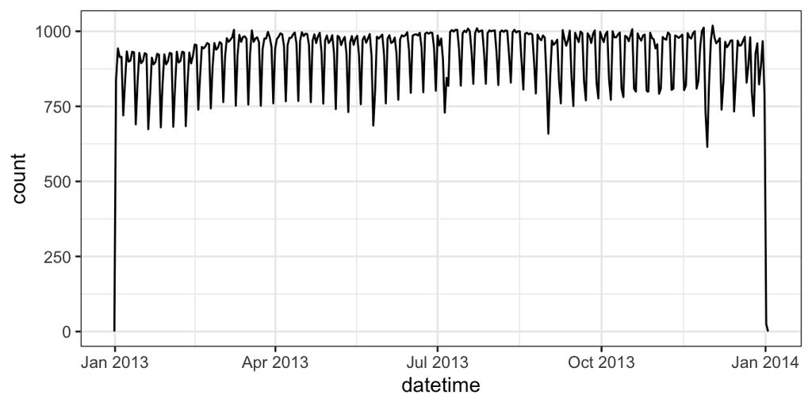

  ```r
  ggplot(flights, aes(x = datetime)) +
    geom_freqpoly(bins = 365)
  ```

- It also makes it easier to filter by date using`as_date()` and `ymd`

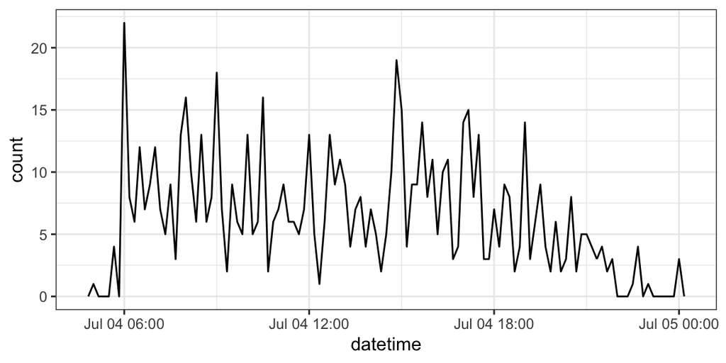

  ```r
  flights %>%
    filter(as_date(datetime) == ymd(20130704)) %>%
    ggplot(aes(x = datetime)) +
    geom_freqpoly(binwidth = 600)
  ```

## 4.1 Use `as_date()` and `as_datetime()` to coerce objects to dates/times

- I used `as_date()` in the previous example. This function will *try* to coerce an object to a date. Sometimes successfully! It is particularly useful for extracting the date component of a `POSIXct` object.
- `as_datetime()` tries to coerce an object to a `POSIXct` object.

## 4.2 **Exercise**:

1. Create a date variable from the following data frame. Then filter out all rows before Feb 1, 2010. If you finish early, try repeat by converting the month variable to a numeric representation of the month without using month_num.

   ```r
   fake <- tribble(~year, ~month, ~day, ~month_num,
                   ##----/-------/----------------
                   2018,  "Oct",  1,    10,
                   2011,  "Nov",  2,    11,
                   2019,  "Dec",  3,    12,
                   2010,  "JAN",  5,     1,
                   1999,  "MAr",  1,     3,
                   1987,  "ApR",  3,     4,
                   2020,  "maY",  2,     5,
                   2010,  "May",  4,     5)
   ```

# 5 `lubridate` has Functions for Getting/Setting Components of a date-time

## 5.1 Getting or extracting the component of a date-time

- `year()` extracts the year.
- `month()` extracts the month.
- `week()` extracts the week.
- `mday()` extracts the day of the month (1, 2, 3, …).
- `wday()` extracts the day of the week (Saturday, Sunday, Monday …).
- `yday()` extracts the day of the year (1, 2, 3, …)
- `hour()` extracts the hour.
- `minute()` extract the minute.
- `second()` extracts the second.

  ```r
  ddat <- mdy_hms("01/02/1970 03:51:44")
  ddat
  ```

  ```
  ## [1] "1970-01-02 03:51:44 UTC"
  ```

  ```r
  year(ddat)
  ```

  ```
  ## [1] 1970
  ```

  ```r
  month(ddat, label = TRUE)
  ```

  ```
  ## [1] Jan
  ## 12 Levels: Jan < Feb < Mar < Apr < May < Jun < Jul < Aug < Sep < ... < Dec
  ```

  ```r
  week(ddat)
  ```

  ```
  ## [1] 1
  ```

  ```r
  mday(ddat)
  ```

  ```
  ## [1] 2
  ```

  ```r
  wday(ddat, label = TRUE)
  ```

  ```
  ## [1] Fri
  ## Levels: Sun < Mon < Tue < Wed < Thu < Fri < Sat
  ```

  ```r
  yday(ddat)
  ```

  ```
  ## [1] 2
  ```

  ```r
  hour(ddat)
  ```

  ```
  ## [1] 3
  ```

  ```r
  minute(ddat)
  ```

  ```
  ## [1] 51
  ```

  ```r
  second(ddat)
  ```

  ```
  ## [1] 44
  ```

### 5.1.1 **Exercise**:

1. Load the `wmata_ridership` data frame into R from https://dcgerard.github.io/stat_412_612/data/wmata_ridership.csv. Exclude any days from 2004. For each month, calculate the proportion of rides made on a given day of the month (1 to 31). Then make box plots of the proportions of ridership vs day of the weak.

## 5.2 Setting the component of a date-time

- You can use the same functions to set or overwrite components of a date-time.

  ```r
  ddat <- mdy_hms("01/02/1970 03:51:44")
  ddat
  ```

  ```
  ## [1] "1970-01-02 03:51:44 UTC"
  ```

  ```r
  year(ddat) <- 1988
  ddat
  ```

  ```
  ## [1] "1988-01-02 03:51:44 UTC"
  ```

## 5.3 Rounding Date-Times

- You can round to the levels of individual components

  ```r
  ddat <- mdy_hms("01/04/1970 03:51:44")
  ddat
  ```

  ```
  ## [1] "1970-01-04 03:51:44 UTC"
  ```

  ```r
  round_date(ddat, unit = "year")
  ```

  ```
  ## [1] "1970-01-01 UTC"
  ```

  ```r
   round_date(ddat, unit = "month")
  ```

  ```
  ## [1] "1970-01-01 UTC"
  ```

  ```r
   round_date(ddat, unit = "day")
  ```

  ```
  ## [1] "1970-01-04 UTC"
  ```

  ```r
   round_date(ddat, unit = "hour")
  ```

  ```
  ## [1] "1970-01-04 04:00:00 UTC"
  ```

- For rounding date-times exactly halfway between two consecutive units, the convention is to round up.

  ```r
  ddat <- mdy_hms("01/04/1970 12:30:00")
   round_date(ddat, unit = "hour")
  ```

  ```
  ## [1] "1970-01-04 13:00:00 UTC"
  ```

  ```r
   ddat <- mdy_hms("02/14/1970 12:00:00")
   round_date(ddat, unit = "day")
  ```

  ```
  ## [1] "1970-02-15 UTC"
  ```

  ```r
   ddat <- mdy_hms("02/14/1970 24:00:00")
   round_date(ddat, unit = "month")
  ```

  ```
  ## [1] "1970-03-01 UTC"
  ```

# 6 Three Different Types of Time Spans

## 6.1 **Durations** - Keeping track of Seconds

- To count the number of seconds between two dates, use a `duration`. Durations record the exact number of seconds in a time span. Read about durations to see that they don’t always match the number of hours, months or days you might calculate.

  ```r
  help("Duration-class")
  ```

- Durations allow exact comparisons with other durations.
- We can find out [Patrick Stewart’s](https://en.wikipedia.org/wiki/Patrick_Stewart) “approximate” age using durations

  ```r
  d1 <- ymd(19400713)
  d2 <- today()
  agesec <- as.duration(d2 - d1)
  agesec
  ```

  ```
  ## [1] "2510006400s (~79.54 years)"
  ```

- Create durations from years with `dyears()`, from days with `ddays()`, etc…

  ```r
  dyears(1)
  ```

  ```
  ## [1] "31536000s (~52.14 weeks)"
  ```

  ```r
  ddays(1)
  ```

  ```
  ## [1] "86400s (~1 days)"
  ```

  ```r
  dhours(1)
  ```

  ```
  ## [1] "3600s (~1 hours)"
  ```

  ```r
  dminutes(1)
  ```

  ```
  ## [1] "60s (~1 minutes)"
  ```

  ```r
  dseconds(1)
  ```

  ```
  ## [1] "1s"
  ```

- You can add durations to date-times, but you always add *seconds*, so if there is a daylight savings change, you get weird results (add a day but the time is not the same as the time the previous day).

  ```r
  one_pm <- ymd_hms("2016-03-12 13:00:00", tz = "America/New_York")
  one_pm
  ```

  ```
  ## [1] "2016-03-12 13:00:00 EST"
  ```

  ```r
  one_pm + ddays(1)
  ```

  ```
  ## [1] "2016-03-13 14:00:00 EDT"
  ```

## 6.2 Periods

- Periods track the change in the human “clock time” between two date-times.
- They ignore actual physical time spans.
- Adding a `period` takes into account daylight savings.

  ```r
  one_pm
  ```

  ```
  ## [1] "2016-03-12 13:00:00 EST"
  ```

  ```r
  one_pm + days(1)
  ```

  ```
  ## [1] "2016-03-13 13:00:00 EDT"
  ```

- Read help for more about periods and the unintuitive calculations that can result if not careful.

  ```r
  help("Period-class")
  ymd(19800128) + months(1)
  ymd(19800131) + months(1)
  ```

## 6.3 Intervals

- Intervals record time spans as a sequence of seconds that begin at a specified date.
- Intervals are like durations, but with an associated start time.
- Intervals and durations are good for physical processes that don’t care about human clock time
- You can read more about intervals with

  ```r
  help("Interval-class")
  ```

- Divide an interval by a duration to determine its physical length,
- Divide an interval by a period to determine its implied length in clock time.

## 6.4 **Exercise**

1. How long of a time-span is covered in the WMATA ridership dataset?

# 7 Time Zones

- Time zones are specified using the `tz` or `tzone` arguments (for example, in the call to `ymd_hms()` above).
- Time zones are specified by “content/city.” For example, `"America/New_York"` and `"Europe_Paris"`
- You can see a complete list of time zones with `OlsonNames()`.
- The default time zone is `UTC` (which has no daylight savings). Coordinated Universal Time *UTC) is the successor time standard to Greenwich Mean Time (GMT) which is a specific time zone.
- You usually don’t have to worry about timezones unless they loaded incorrectly. For example, R might think it’s `UTC` even though it should be `America/New_York` and then forget daylight savings.
- If a date-time is labelled with the incorrect time zone, use `force_tz()`.

  ```r
  d1 <- ymd_hms("20140101 10:01:11")
  d1
  ```

  ```
  ## [1] "2014-01-01 10:01:11 UTC"
  ```

  ```r
  force_tz(d1, tzone = "America/New_York")
  ```

  ```
  ## [1] "2014-01-01 10:01:11 EST"
  ```

- If the timezone is correct, but you want to change it, use `with_tz()`.

  ```r
  with_tz(d1, tzone = "America/New_York")
  ```

  ```
  ## [1] "2014-01-01 05:01:11 EST"
  ```